# Project 1 — C02 Emissions vs. GDP per Capita (1990–2020)

Sang In Byeon

```r
knitr::opts_chunk$set(echo = TRUE, message = FALSE, warning = FALSE, fig.width = 7, fig.height = 4.5)
# install.packages(c("tidyverse","wbstats","janitor","skimr","broom","gt","GGally","readr","glue","yardstick"))
library(tidyverse)
library(wbstats)
library(janitor)
library(skimr)
library(broom)
library(gt)
library(GGally)
library(readr)
library(glue)
library(yardstick)
set.seed(301)
```

# Intro and Problem

For Project 1, I wanted to see the relationship between **CO₂ emissions per capita** and **GDP per capita** across countries from **1990–2020**.  
**Question:** *To what extent does a country’s income level influence its per-capita CO₂ emissions, and how effectively can statistical models capture and explain this relationship?*

# Loading the Data

I first try to load data from the **World Bank** using `wbstats`. If unavailable, I **fall back** to **Our World in Data (OWID)** and reattach World Bank **region** and **income** metadata so the rest is identical.

```r
co2_code <- "EN.ATM.CO2E.PC"      # CO2 (metric tons per person)
gdp_code <- "NY.GDP.PCAP.KD"      # GDP per capita (constant 2015 USD)

fetch_worldbank <- function() {
  wb_data(
    indicator   = c(co2_pc = co2_code, gdp_pc = gdp_code),
    start_date  = 1990,
    end_date    = 2020,
    return_wide = TRUE
  ) %>%
    clean_names() %>%
    filter(!is.na(gdp_pc), !is.na(co2_pc)) %>%
    mutate(
      year    = as.integer(date),
      iso3c   = iso3c,
      country = country,
      region  = region,
      income  = income_level
    ) %>%
    select(iso3c, country, year, region, income, gdp_pc, co2_pc)
}

fetch_owid <- function() {
  owid <- read_csv("https://raw.githubusercontent.com/owid/co2-data/master/owid-co2-data.csv",
                   show_col_types = FALSE) %>%
    clean_names() %>%
    filter(!is.na(population), !is.na(gdp), !is.na(co2_per_capita)) %>%
    transmute(
      iso3c   = iso_code,
      country = country,
      year    = year,
      co2_pc  = co2_per_capita,
      gdp_pc  = gdp / population
    ) %>%
    filter(year >= 1990, year <= 2020)

  meta <- wb_countries() %>%
    transmute(iso3c, region = region, income = income_level)

  owid %>% left_join(meta, by = "iso3c") %>% drop_na(region, income)
}

dat <- tryCatch(fetch_worldbank(), error = function(e) NULL)

source_label <- if (is.null(dat)) {
  dat <<- fetch_owid()
  "OWID (fallback) + WB metadata"
} else {
  "World Bank (wbstats)"
}

glue("Data source used: {source_label}; rows: {nrow(dat)}")
```

```
## Data source used: OWID (fallback) + WB metadata; rows: 5050
```

```r
dat <- dat %>% clean_names()
dim(dat)
```

```
## [1] 5050    7
```

```r
head(dat) %>% gt()
```

| iso3c | country | year | co2_pc | gdp_pc | region | income |
| --- | --- | --- | --- | --- | --- | --- |
| AFG | Afghanistan | 1990 | 0.168 | 1084.7043 | Middle East, North Africa, Afghanistan & Pakistan | Low income |
| AFG | Afghanistan | 1991 | 0.156 | 984.3518 | Middle East, North Africa, Afghanistan & Pakistan | Low income |
| AFG | Afghanistan | 1992 | 0.112 | 954.7072 | Middle East, North Africa, Afghanistan & Pakistan | Low income |
| AFG | Afghanistan | 1993 | 0.100 | 658.1321 | Middle East, North Africa, Afghanistan & Pakistan | Low income |
| AFG | Afghanistan | 1994 | 0.089 | 487.3518 | Middle East, North Africa, Afghanistan & Pakistan | Low income |
| AFG | Afghanistan | 1995 | 0.083 | 721.1792 | Middle East, North Africa, Afghanistan & Pakistan | Low income |

# Quick Overview of the Data

```r
skim(dat %>% select(gdp_pc, co2_pc))
```

Data summary

| Name | dat %>% select(gdp_pc, co… |
| --- | --- |
| Number of rows | 5050 |
| Number of columns | 2 |
| _______________________ |  |
| Column type frequency: |  |
| numeric | 2 |
| ________________________ |  |
| Group variables | None |

**Variable type: numeric**

| skim_variable | n_missing | complete_rate | mean | sd | p0 | p25 | p50 | p75 | p100 | hist |
| --- | --- | --- | --- | --- | --- | --- | --- | --- | --- | --- |
| gdp_pc | 0 | 1 | 13889.13 | 16041.75 | 361.19 | 2762.56 | 8034.56 | 19324.86 | 163531.58 | ▇▁▁▁▁ |
| co2_pc | 0 | 1 | 4.94 | 8.46 | 0.02 | 0.59 | 2.54 | 6.77 | 364.69 | ▇▁▁▁▁ |

# Pre-Processing the Data

I cleaned up the dataset by standardizing column names and removing any missing values. Then I added a log-transformed version of GDP per capita to make the relationship more linear for modeling. Finally, I split the data into 80% for training and 20% for testing to evaluate how well the model performs on new data.

```r
dat_model <- dat %>% mutate(log_gdp_pc = log1p(gdp_pc))

set.seed(301)
idx   <- sample(seq_len(nrow(dat_model)), size = 0.8*nrow(dat_model))
train <- dat_model[idx, ]
test  <- dat_model[-idx, ]

nrow(train); nrow(test)
```

```
## [1] 4040
```

```
## [1] 1010
```

# Data Exploration

## Overall Relationship (Scatter with LOESS)

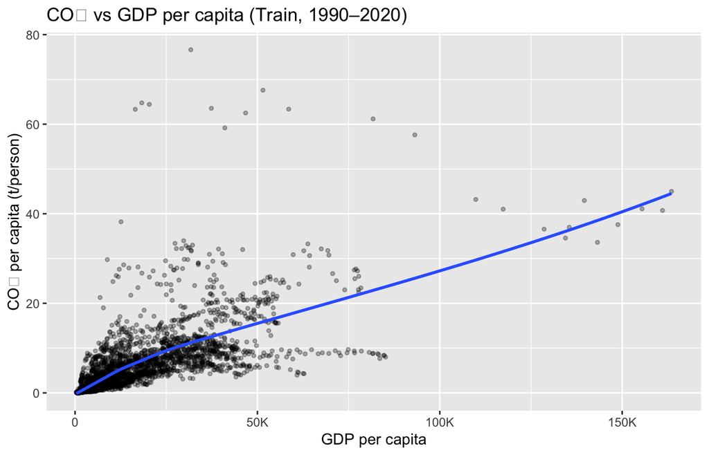

```r
train %>%
  ggplot(aes(x = gdp_pc, y = co2_pc)) +
  geom_point(alpha = 0.3, size = 1) +
  scale_x_continuous(labels = scales::label_number(scale_cut = scales::cut_short_scale())) +
  labs(x = "GDP per capita", y = "CO₂ per capita (t/person)",
       title = "CO₂ vs GDP per capita (Train, 1990–2020)") +
  geom_smooth(method = "loess", se = FALSE)
```

**Observation.** Emissions per person rise with income, with diminishing returns at high income levels.

## Facet by Income Group

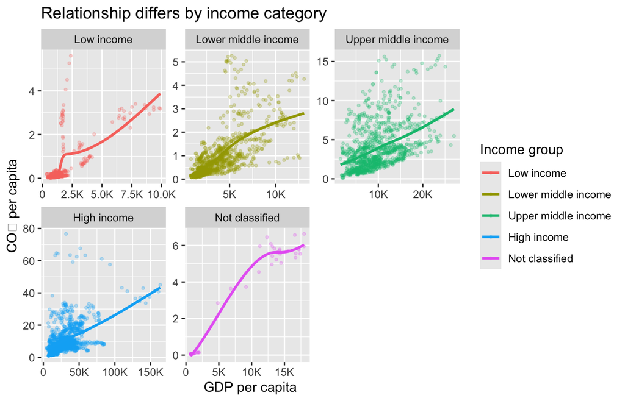

```r
train %>%
  mutate(income = forcats::fct_relevel(income, "Low income","Lower middle income","Upper middle income","High income")) %>%
  ggplot(aes(gdp_pc, co2_pc, color = income)) +
  geom_point(alpha = 0.25, size = 0.8) +
  geom_smooth(se = FALSE) +
  scale_x_continuous(labels = scales::label_number(scale_cut = scales::cut_short_scale())) +
  labs(x = "GDP per capita", y = "CO₂ per capita", color = "Income group",
       title = "Relationship differs by income category") +
  facet_wrap(~ income, scales = "free")
```

# Building the Predictive Model

I start with a **simple linear regression** using only log(GDP per capita).

```r
m1 <- lm(co2_pc ~ log_gdp_pc, data = train)
summary(m1) %>% broom::tidy()
```

```
## # A tibble: 2 × 5
##   term        estimate std.error statistic p.value
##   <chr>          <dbl>     <dbl>     <dbl>   <dbl>
## 1 (Intercept)   -27.5     0.590      -46.6       0
## 2 log_gdp_pc      3.64    0.0656      55.4       0
```

# Plotting the Training Model

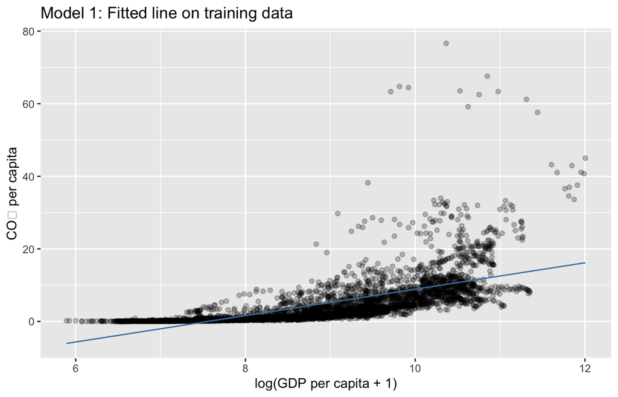

```r
train %>%
  mutate(.fitted = predict(m1, newdata = train)) %>%
  ggplot(aes(log_gdp_pc, co2_pc)) +
  geom_point(alpha = 0.25) +
  geom_line(aes(y = .fitted), color = "steelblue") +
  labs(x = "log(GDP per capita + 1)", y = "CO₂ per capita",
       title = "Model 1: Fitted line on training data")
```

# Plotting the Testing Model

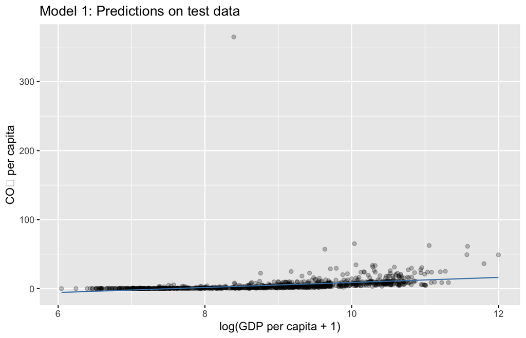

```r
test %>%
  mutate(.fitted = predict(m1, newdata = test)) %>%
  ggplot(aes(log_gdp_pc, co2_pc)) +
  geom_point(alpha = 0.25) +
  geom_line(aes(y = .fitted), color = "steelblue") +
  labs(x = "log(GDP per capita + 1)", y = "CO₂ per capita",
       title = "Model 1: Predictions on test data")
```

# Basic Model Summary

```r
pred_m1 <- augment(m1, newdata = test)
tibble(
  model = "Linear (log GDPpc)",
  rmse  = yardstick::rmse_vec(truth = test$co2_pc, estimate = pred_m1$.fitted),
  mae   = yardstick::mae_vec (truth = test$co2_pc, estimate = pred_m1$.fitted),
  r2    = yardstick::rsq_vec (truth = test$co2_pc, estimate = pred_m1$.fitted)
) %>% gt() %>% fmt_number(decimals = 3)
```

| model | rmse | mae | r2 |
| --- | --- | --- | --- |
| Linear (log GDPpc) | 12.625 | 3.534 | 0.098 |

# Plotting the Residuals

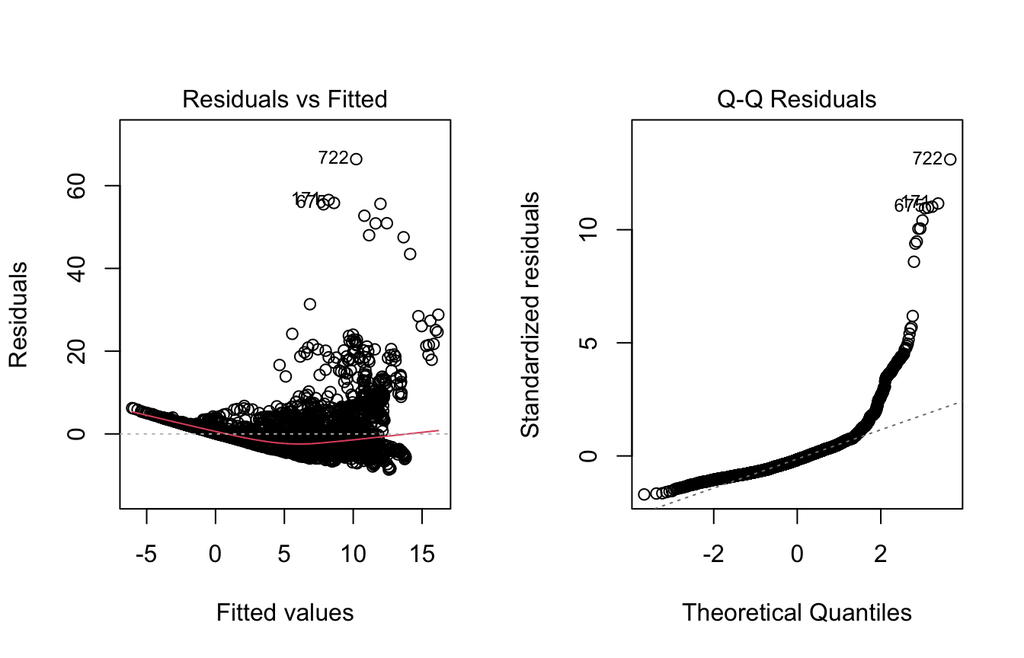

```r
par(mfrow = c(1,2))
plot(m1, which = 1)  # residuals vs fitted
plot(m1, which = 2)  # QQ plot
```

```r
par(mfrow = c(1,1))
```

# Improving the Model

I add **income group** and **region** as categorical predictors to capture structural differences.

```r
m2 <- lm(co2_pc ~ log_gdp_pc + income + region, data = train)
summary(m2) %>% broom::tidy()
```

```
## # A tibble: 12 × 5
##    term                                    estimate std.error statistic  p.value
##    <chr>                                      <dbl>     <dbl>     <dbl>    <dbl>
##  1 (Intercept)                              -12.6       1.38     -9.10  1.42e-19
##  2 log_gdp_pc                                 2.29      0.133    17.2   4.08e-64
##  3 incomeLow income                          -4.46      0.471    -9.47  4.76e-21
##  4 incomeLower middle income                 -5.75      0.346   -16.6   6.07e-60
##  5 incomeNot classified                      -2.72      0.687    -3.96  7.76e- 5
##  6 incomeUpper middle income                 -3.75      0.240   -15.7   9.75e-54
##  7 regionEurope & Central Asia               -1.16      0.264    -4.41  1.05e- 5
##  8 regionLatin America & Caribbean           -1.98      0.293    -6.75  1.69e-11
##  9 regionMiddle East, North Africa, Afgha…    4.02      0.295    13.6   2.06e-41
## 10 regionNorth America                        6.03      0.680     8.87  1.09e-18
## 11 regionSouth Asia                           0.354     0.529     0.670 5.03e- 1
## 12 regionSub-Saharan Africa                   0.594     0.286     2.08  3.76e- 2
```

# Building the Improved Predictive Model

```r
pred_m2 <- augment(m2, newdata = test)

bind_rows(
  tibble(model = "Linear (log GDPpc)",
         rmse  = yardstick::rmse_vec(truth = test$co2_pc, estimate = pred_m1$.fitted),
         mae   = yardstick::mae_vec (truth = test$co2_pc, estimate = pred_m1$.fitted),
         r2    = yardstick::rsq_vec (truth = test$co2_pc, estimate = pred_m1$.fitted)),
  tibble(model = "Multiple (+ income + region)",
         rmse  = yardstick::rmse_vec(truth = test$co2_pc, estimate = pred_m2$.fitted),
         mae   = yardstick::mae_vec (truth = test$co2_pc, estimate = pred_m2$.fitted),
         r2    = yardstick::rsq_vec (truth = test$co2_pc, estimate = pred_m2$.fitted))
) %>% gt() %>% fmt_number(decimals = 3)
```

| model | rmse | mae | r2 |
| --- | --- | --- | --- |
| Linear (log GDPpc) | 12.625 | 3.534 | 0.098 |
| Multiple (+ income + region) | 12.172 | 3.094 | 0.162 |

# Plotting the Improved Training Model

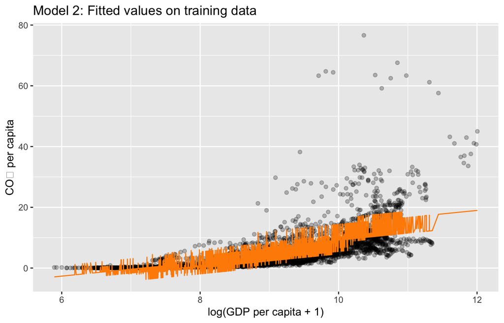

```r
train %>%
  mutate(.fitted = predict(m2, newdata = train)) %>%
  ggplot(aes(log_gdp_pc, co2_pc)) +
  geom_point(alpha = 0.25) +
  geom_line(aes(y = .fitted), color = "darkorange") +
  labs(x = "log(GDP per capita + 1)", y = "CO₂ per capita",
       title = "Model 2: Fitted values on training data")
```

# Plotting the Improved Testing Model

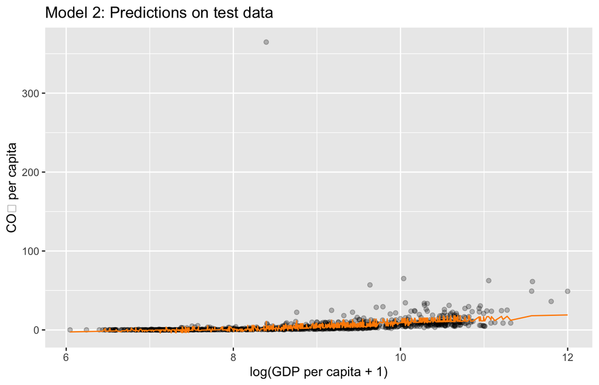

```r
test %>%
  mutate(.fitted = predict(m2, newdata = test)) %>%
  ggplot(aes(log_gdp_pc, co2_pc)) +
  geom_point(alpha = 0.25) +
  geom_line(aes(y = .fitted), color = "darkorange") +
  labs(x = "log(GDP per capita + 1)", y = "CO₂ per capita",
       title = "Model 2: Predictions on test data")
```